# NYPD Shooting Incidents by Borough

K. Chu

9/4/2021

I thought about what would be an interesting question to answer, and I thought that finding the most dangerous borough and the safest borough would be something I wanted to know.

```r
library(tidyverse)
library(lubridate)
url_in <- "https://data.cityofnewyork.us/api/views/833y-fsy8/rows.csv?accessType=DOWNLOAD"

incidents <- read_csv(url_in)
summary(incidents)
```

```
##   INCIDENT_KEY        OCCUR_DATE         OCCUR_TIME            BORO
##  Min.   :  9953245   Length:23568       Length:23568       Length:23568
##  1st Qu.: 55317014   Class :character   Class :character   Class :character
##  Median : 83365370   Mode  :character   Mode  :character   Mode  :character
##  Mean   :102218616
##  3rd Qu.:150772442
##  Max.   :222473262
##
##     PRECINCT      JURISDICTION_CODE LOCATION_DESC      STATISTICAL_MURDER_FLAG
##  Min.   :  1.00   Min.   :0.0000    Length:23568       Mode :logical
##  1st Qu.: 44.00   1st Qu.:0.0000    Class :character   FALSE:19080
##  Median : 69.00   Median :0.0000    Mode  :character   TRUE :4488
##  Mean   : 66.21   Mean   :0.3323
##  3rd Qu.: 81.00   3rd Qu.:0.0000
##  Max.   :123.00   Max.   :2.0000
##                   NA's   :2
##  PERP_AGE_GROUP       PERP_SEX          PERP_RACE         VIC_AGE_GROUP
##  Length:23568       Length:23568       Length:23568       Length:23568
##  Class :character   Class :character   Class :character   Class :character
##  Mode  :character   Mode  :character   Mode  :character   Mode  :character
##
##
##
##
##    VIC_SEX            VIC_RACE           X_COORD_CD        Y_COORD_CD
##  Length:23568       Length:23568       Min.   : 914928   Min.   :125757
##  Class :character   Class :character   1st Qu.: 999900   1st Qu.:182565
##  Mode  :character   Mode  :character   Median :1007645   Median :193482
##                                        Mean   :1009363   Mean   :207312
##                                        3rd Qu.:1016807   3rd Qu.:239163
##                                        Max.   :1066815   Max.   :271128
##
##     Latitude       Longitude        Lon_Lat
##  Min.   :40.51   Min.   :-74.25   Length:23568
##  1st Qu.:40.67   1st Qu.:-73.94   Class :character
##  Median :40.70   Median :-73.92   Mode  :character
##  Mean   :40.74   Mean   :-73.91
##  3rd Qu.:40.82   3rd Qu.:-73.88
##  Max.   :40.91   Max.   :-73.70
##
```

I have gotten my data from the City of New York’s data website. This is their shooting incident data, as recorded from 2006 all the way until the end of 2020.

It contains quite a lot of information, such as some information about the perpetrator and the victim. There are fields for the race, age group, and sex of both victims and perpetrators. It also includes whether the victim was murdered.

It also includes location information about each shooting, even up to latitude and longitude! It even includes a description of the location, as well as the precinct and jurisdiction code of each location where the shootings take place.

Of course, it also includes the time and date of each shooting.

```r
incidents <-incidents %>%
  mutate(OCCUR_DATE = mdy(OCCUR_DATE),  # convert OCCUR_DATE to date
         BORO = factor(BORO),
         LOCATION_DESC = factor(LOCATION_DESC),
         STATISTICAL_MURDER_FLAG = factor(STATISTICAL_MURDER_FLAG),
         PERP_AGE_GROUP = factor(PERP_AGE_GROUP),
         PERP_SEX = factor(PERP_SEX),
         PERP_RACE = factor(PERP_RACE),
         VIC_AGE_GROUP = factor(VIC_AGE_GROUP),
         VIC_SEX = factor(VIC_SEX),
         VIC_RACE = factor(VIC_RACE)) %>%
  # remove unneeded columns
  select(-c(INCIDENT_KEY, PRECINCT, JURISDICTION_CODE,
            X_COORD_CD, Y_COORD_CD, Latitude, Longitude, Lon_Lat)) %>%
  # replace the NA entries as "unknown" or some variation
  replace_na(list(LOCATION_DESC="NONE",
                  PERP_AGE_GROUP="UNKNOWN",
                  PERP_SEX="U",
                  PERP_RACE="UNKNOWN"))

summary(incidents)
```

```
##    OCCUR_DATE          OCCUR_TIME                   BORO
##  Min.   :2006-01-01   Length:23568       BRONX        :6700
##  1st Qu.:2008-12-30   Class :character   BROOKLYN     :9722
##  Median :2012-02-26   Mode  :character   MANHATTAN    :2921
##  Mean   :2012-10-03                      QUEENS       :3527
##  3rd Qu.:2016-02-28                      STATEN ISLAND: 698
##  Max.   :2020-12-31
##
##                    LOCATION_DESC   STATISTICAL_MURDER_FLAG PERP_AGE_GROUP
##  NONE                     :13756   FALSE:19080             UNKNOWN:11615
##  MULTI DWELL - PUBLIC HOUS: 4230   TRUE : 4488             18-24  : 5448
##  MULTI DWELL - APT BUILD  : 2551                           25-44  : 4613
##  PVT HOUSE                :  858                           <18    : 1354
##  GROCERY/BODEGA           :  572                           45-64  :  481
##  BAR/NIGHT CLUB           :  558                           65+    :   54
##  (Other)                  : 1043                           (Other):    3
##  PERP_SEX                           PERP_RACE     VIC_AGE_GROUP   VIC_SEX
##  F:  334   AMERICAN INDIAN/ALASKAN NATIVE:    2   <18    : 2525   F: 2195
##  M:13305   ASIAN / PACIFIC ISLANDER      :  120   18-24  : 9000   M:21353
##  U: 9929   BLACK                         : 9855   25-44  :10287   U:   20
##            BLACK HISPANIC                : 1081   45-64  : 1536
##            UNKNOWN                       :10294   65+    :  155
##            WHITE                         :  255   UNKNOWN:   65
##            WHITE HISPANIC                : 1961
##                            VIC_RACE
##  AMERICAN INDIAN/ALASKAN NATIVE:    9
##  ASIAN / PACIFIC ISLANDER      :  320
##  BLACK                         :16846
##  BLACK HISPANIC                : 2244
##  UNKNOWN                       :  102
##  WHITE                         :  615
##  WHITE HISPANIC                : 3432
```

There are fields where the entries are blank. Examples include:

- LOCATION_DESC
- PERP_AGE_GROUP
- PERP_SEX
- PERP_RACE

What I did was to change the blank entries to reflect the same value used to denote an unknown value.

```r
# sort by date
incidents <- incidents %>%
  arrange(OCCUR_DATE)

# use month instead of specific day
incidents <- incidents %>%
  mutate(Occur_Month = floor_date(OCCUR_DATE, "month"))

incidents$rec <- 1

# create a column for cumulative shootings by borough
with_cumulative_cases <- incidents %>%
  group_by(BORO) %>%
  mutate(Cumulative_Shootings = cumsum(rec)) %>%
  select(-rec) %>%
  ungroup()

# get the number of cumulative shootings per month by borough
with_cumulative_cases <- with_cumulative_cases %>%
  group_by(Occur_Month, BORO) %>%
  top_n(1, Cumulative_Shootings) %>%
  select(c(Occur_Month, BORO, Cumulative_Shootings)) %>%
  ungroup()

# divide the cases by borough
queens <- with_cumulative_cases %>%
  filter(BORO == "QUEENS")

manhattan <- with_cumulative_cases %>%
  filter(BORO == "MANHATTAN")

brooklyn <- with_cumulative_cases %>%
  filter(BORO == "BROOKLYN")

bronx <- with_cumulative_cases %>%
  filter(BORO == "BRONX")

staten_island <- with_cumulative_cases %>%
  filter(BORO == "STATEN ISLAND")
```

Here, I tried grouping the shootings by borough. I also realized that I didn’t quite need information about the victim and the perpetrator, so I simply removed their columns.

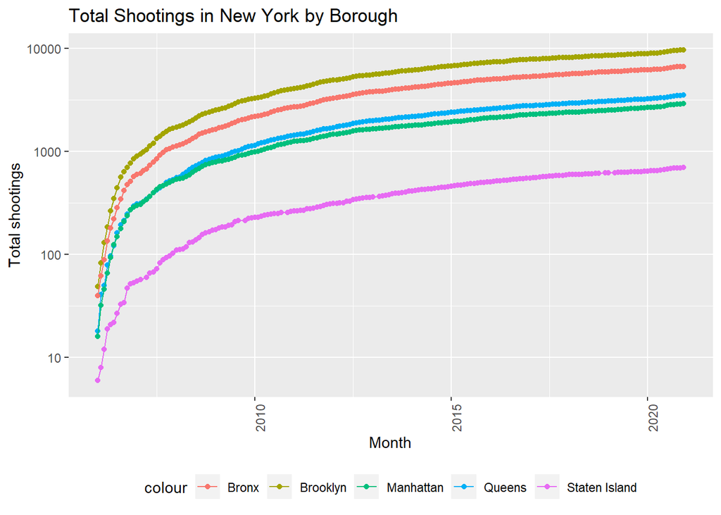

```r
queens %>%
  ggplot(aes(x = Occur_Month, y = Cumulative_Shootings)) +
  geom_line(aes(color="Queens")) +
  geom_point(aes(color="Queens")) +

  geom_line(data=manhattan, aes(color="Manhattan")) +
  geom_point(data=manhattan, aes(color="Manhattan")) +

  geom_line(data=brooklyn, aes(color="Brooklyn")) +
  geom_point(data=brooklyn, aes(color="Brooklyn")) +

  geom_line(data=bronx, aes(color="Bronx")) +
  geom_point(data=bronx, aes(color="Bronx")) +

  geom_line(data=staten_island, aes(color="Staten Island")) +
  geom_point(data=staten_island, aes(color="Staten Island")) +

  scale_y_log10() +
  theme(legend.position="bottom",
        axis.text.x = element_text(angle=90)) +
  labs(title="Total Shootings in New York by Borough",
       y="Total shootings",
       x="Month")
```

The graphs show that Bronx and Brooklyn are the places with the most number of shooting incidents while Staten Island has the least number of shooting incidents. It has led me to ask if Bronx and Brooklyn truly are the most dangerous places in New York and if Staten Island is the safest place in New York.

```r
# add new shootings column

queens <- queens %>%
  mutate(New_Shootings = Cumulative_Shootings - lag(Cumulative_Shootings))
queens$New_Shootings <- ifelse(is.na(queens$New_Shootings),
                               queens$Cumulative_Shootings,
                               queens$New_Shootings)

manhattan <- manhattan %>%
  mutate(New_Shootings = Cumulative_Shootings - lag(Cumulative_Shootings))
manhattan$New_Shootings <- ifelse(is.na(manhattan$New_Shootings),
                               manhattan$Cumulative_Shootings,
                               manhattan$New_Shootings)

brooklyn <- brooklyn %>%
  mutate(New_Shootings = Cumulative_Shootings - lag(Cumulative_Shootings))
brooklyn$New_Shootings <- ifelse(is.na(brooklyn$New_Shootings),
                               brooklyn$Cumulative_Shootings,
                               brooklyn$New_Shootings)

bronx <- bronx %>%
  mutate(New_Shootings = Cumulative_Shootings - lag(Cumulative_Shootings))
bronx$New_Shootings <- ifelse(is.na(bronx$New_Shootings),
                               bronx$Cumulative_Shootings,
                               bronx$New_Shootings)

staten_island <- staten_island %>%
  mutate(New_Shootings = Cumulative_Shootings - lag(Cumulative_Shootings))
staten_island$New_Shootings <- ifelse(is.na(staten_island$New_Shootings),
                               staten_island$Cumulative_Shootings,
                               staten_island$New_Shootings)
```

Here, I added a new column for new shootings. I also made sure that there were no empty fields. I noticed that the first entry was empty because there was no value for lag(Cumulative_Shootings) at that point. For this, I simply copied over the Cumulative_Shootings value for the first month.

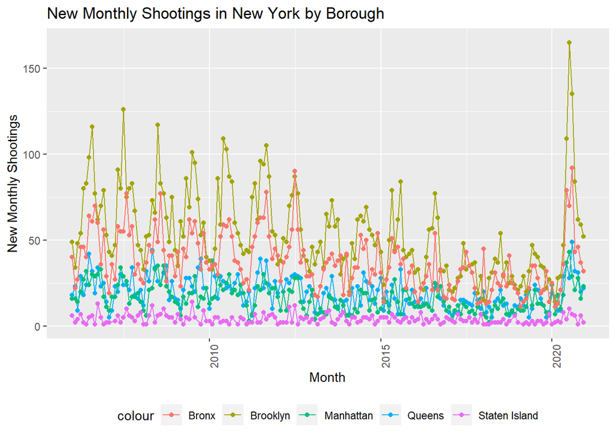

```r
queens %>%
  ggplot(aes(x = Occur_Month, y = New_Shootings)) +
  geom_line(aes(color="Queens")) +
  geom_point(aes(color="Queens")) +

  geom_line(data=manhattan, aes(color="Manhattan")) +
  geom_point(data=manhattan, aes(color="Manhattan")) +

  geom_line(data=brooklyn, aes(color="Brooklyn")) +
  geom_point(data=brooklyn, aes(color="Brooklyn")) +

  geom_line(data=bronx, aes(color="Bronx")) +
  geom_point(data=bronx, aes(color="Bronx")) +

  geom_line(data=staten_island, aes(color="Staten Island")) +
  geom_point(data=staten_island, aes(color="Staten Island")) +

  theme(legend.position="bottom",
       axis.text.x = element_text(angle=90)) +
  labs(title="New Monthly Shootings in New York by Borough",
       y="New Monthly Shootings",
       x="Month")
```

According to this graph, there appear to be several sharp spikes in shooting incidents in Brooklyn and Bronx. The other three boroughs, Manhattan, Queens, and Staten Island, appear to be more muted by comparison.

However, there is an even higher surge in shooting incidents in 2020. This increase is particularly sharp in Brooklyn and Bronx. What caused this spike? This sharp increase is unprecedented, especially in Brooklyn.

```r
# queens monthly model
mod_queens <- lm(New_Shootings ~ Occur_Month, data=queens)
summary(mod_queens)
```

```
##
## Call:
## lm(formula = New_Shootings ~ Occur_Month, data = queens)
##
## Residuals:
##     Min      1Q  Median      3Q     Max
## -18.916  -6.002  -0.947   4.958  34.239
##
## Coefficients:
##              Estimate Std. Error t value Pr(>|t|)
## (Intercept) 49.068431   6.300698   7.788 5.41e-13 ***
## Occur_Month -0.001857   0.000395  -4.701 5.17e-06 ***
## ---
## Signif. codes:  0 '***' 0.001 '**' 0.01 '*' 0.05 '.' 0.1 ' ' 1
##
## Residual standard error: 8.382 on 178 degrees of freedom
## Multiple R-squared:  0.1104, Adjusted R-squared:  0.1054
## F-statistic:  22.1 on 1 and 178 DF,  p-value: 5.168e-06
```

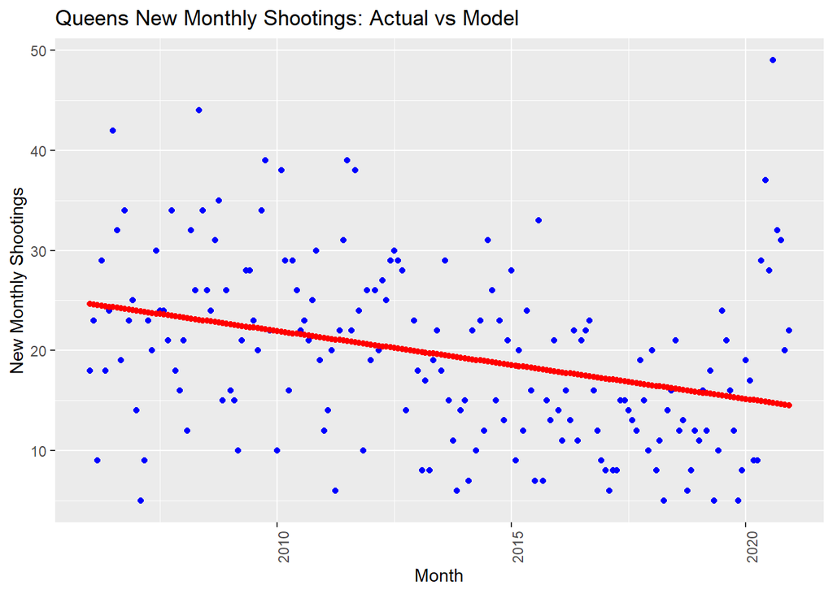

```r
queens_w_pred <- queens %>% mutate(pred = predict(mod_queens))

queens_w_pred %>% ggplot() +
  geom_point(aes(x = Occur_Month, y = New_Shootings), color = "blue") +
  geom_point(aes(x = Occur_Month, y = pred), color = "red") +
  theme(legend.position="bottom",
       axis.text.x = element_text(angle=90)) +
  labs(title="Queens New Monthly Shootings: Actual vs Model",
       y="New Monthly Shootings",
       x="Month")
```

```r
# manhattan monthly model
mod_manhattan <- lm(New_Shootings ~ Occur_Month, data=manhattan)
summary(mod_manhattan)
```

```
##
## Call:
## lm(formula = New_Shootings ~ Occur_Month, data = manhattan)
##
## Residuals:
##     Min      1Q  Median      3Q     Max
## -14.587  -5.435  -1.281   4.234  30.941
##
## Coefficients:
##               Estimate Std. Error t value Pr(>|t|)
## (Intercept) 41.9579895  5.6181933   7.468 3.50e-12 ***
## Occur_Month -0.0016211  0.0003522  -4.602 7.91e-06 ***
## ---
## Signif. codes:  0 '***' 0.001 '**' 0.01 '*' 0.05 '.' 0.1 ' ' 1
##
## Residual standard error: 7.474 on 178 degrees of freedom
## Multiple R-squared:  0.1063, Adjusted R-squared:  0.1013
## F-statistic: 21.18 on 1 and 178 DF,  p-value: 7.914e-06
```

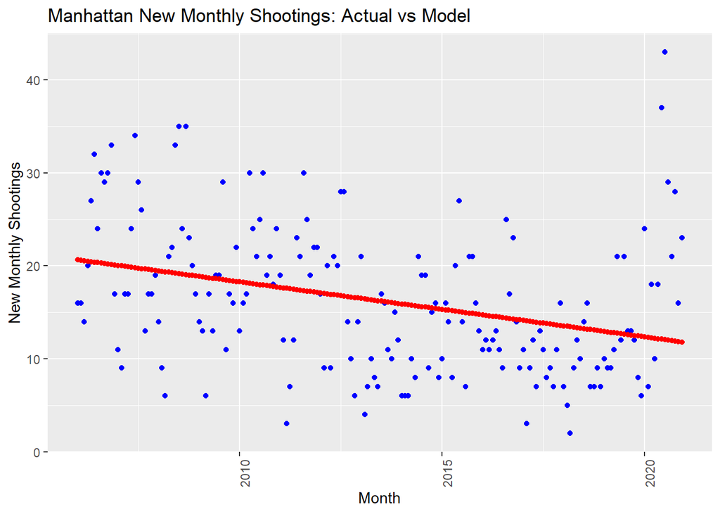

```r
manhattan_w_pred <- manhattan %>% mutate(pred = predict(mod_manhattan))

manhattan_w_pred %>% ggplot() +
  geom_point(aes(x = Occur_Month, y = New_Shootings), color = "blue") +
  geom_point(aes(x = Occur_Month, y = pred), color = "red") +
  theme(legend.position="bottom",
       axis.text.x = element_text(angle=90)) +
  labs(title="Manhattan New Monthly Shootings: Actual vs Model",
       y="New Monthly Shootings",
       x="Month")
```

```r
# brooklyn monthly model
mod_brooklyn <- lm(New_Shootings ~ Occur_Month, data=brooklyn)
summary(mod_brooklyn)
```

```
##
## Call:
## lm(formula = New_Shootings ~ Occur_Month, data = brooklyn)
##
## Residuals:
##     Min      1Q  Median      3Q     Max
## -37.445 -16.322  -5.209  11.184 127.642
##
## Coefficients:
##               Estimate Std. Error t value Pr(>|t|)
## (Intercept) 156.792246  17.711840   8.852 8.46e-16 ***
## Occur_Month  -0.006475   0.001110  -5.832 2.53e-08 ***
## ---
## Signif. codes:  0 '***' 0.001 '**' 0.01 '*' 0.05 '.' 0.1 ' ' 1
##
## Residual standard error: 23.56 on 178 degrees of freedom
## Multiple R-squared:  0.1604, Adjusted R-squared:  0.1557
## F-statistic: 34.01 on 1 and 178 DF,  p-value: 2.533e-08
```

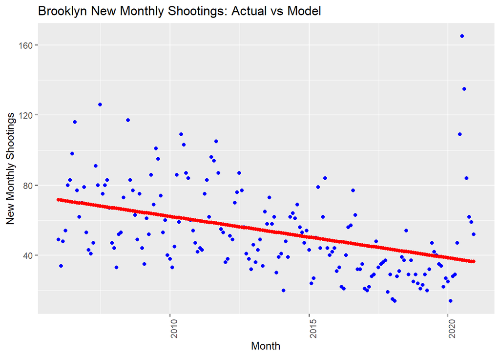

```r
brooklyn_w_pred <- brooklyn %>% mutate(pred = predict(mod_brooklyn))

brooklyn_w_pred %>% ggplot() +
  geom_point(aes(x = Occur_Month, y = New_Shootings), color = "blue") +
  geom_point(aes(x = Occur_Month, y = pred), color = "red") +
  theme(legend.position="bottom",
       axis.text.x = element_text(angle=90)) +
  labs(title="Brooklyn New Monthly Shootings: Actual vs Model",
       y="New Monthly Shootings",
       x="Month")
```

```r
# bronx monthly model
mod_bronx <- lm(New_Shootings ~ Occur_Month, data=bronx)
summary(mod_bronx)
```

```
##
## Call:
## lm(formula = New_Shootings ~ Occur_Month, data = bronx)
##
## Residuals:
##     Min      1Q  Median      3Q     Max
## -27.348 -10.249  -1.947   9.152  64.983
##
## Coefficients:
##              Estimate Std. Error t value Pr(>|t|)
## (Intercept) 99.459591  11.260742   8.832 9.57e-16 ***
## Occur_Month -0.003921   0.000706  -5.554 1.00e-07 ***
## ---
## Signif. codes:  0 '***' 0.001 '**' 0.01 '*' 0.05 '.' 0.1 ' ' 1
##
## Residual standard error: 14.98 on 178 degrees of freedom
## Multiple R-squared:  0.1477, Adjusted R-squared:  0.1429
## F-statistic: 30.85 on 1 and 178 DF,  p-value: 1.001e-07
```

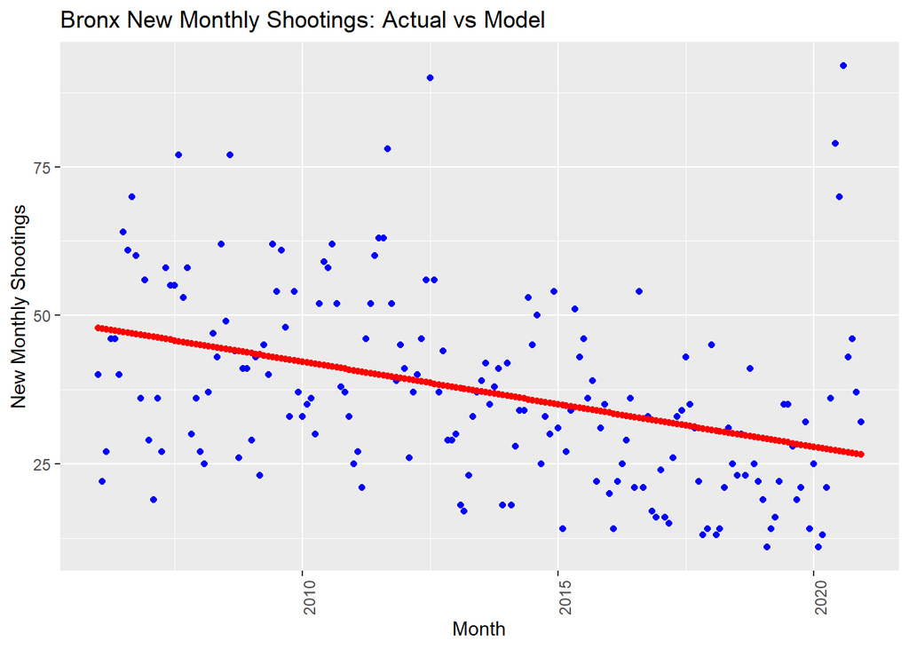

```r
bronx_w_pred <- bronx %>% mutate(pred = predict(mod_bronx))

bronx_w_pred %>% ggplot() +
  geom_point(aes(x = Occur_Month, y = New_Shootings), color = "blue") +
  geom_point(aes(x = Occur_Month, y = pred), color = "red") +
  theme(legend.position="bottom",
       axis.text.x = element_text(angle=90)) +
  labs(title="Bronx New Monthly Shootings: Actual vs Model",
       y="New Monthly Shootings",
       x="Month")
```

```r
# staten island monthly model
mod_staten_island <- lm(New_Shootings ~ Occur_Month, data=staten_island)
summary(mod_staten_island)
```

```
##
## Call:
## lm(formula = New_Shootings ~ Occur_Month, data = staten_island)
##
## Residuals:
##     Min      1Q  Median      3Q     Max
## -3.8066 -2.1444 -0.3015  1.2111  9.5408
##
## Coefficients:
##               Estimate Std. Error t value Pr(>|t|)
## (Intercept)  8.9103165  2.0032624   4.448 1.55e-05 ***
## Occur_Month -0.0003086  0.0001256  -2.457    0.015 *
## ---
## Signif. codes:  0 '***' 0.001 '**' 0.01 '*' 0.05 '.' 0.1 ' ' 1
##
## Residual standard error: 2.616 on 172 degrees of freedom
## Multiple R-squared:  0.03392,    Adjusted R-squared:  0.0283
## F-statistic: 6.039 on 1 and 172 DF,  p-value: 0.01498
```

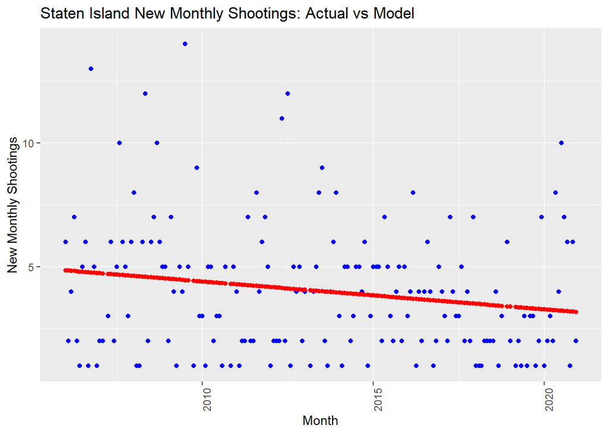

```r
staten_island_w_pred <- staten_island %>% mutate(pred = predict(mod_staten_island))

staten_island_w_pred %>% ggplot() +
  geom_point(aes(x = Occur_Month, y = New_Shootings), color = "blue") +
  geom_point(aes(x = Occur_Month, y = pred), color = "red") +
  theme(legend.position="bottom",
       axis.text.x = element_text(angle=90)) +
  labs(title="Staten Island New Monthly Shootings: Actual vs Model",
       y="New Monthly Shootings",
       x="Month")
```

I try to make a linear model for each of the boroughs.

A linear model isn’t particularly accurate when trying to predict the number of shootings per month. How would our graphs look like when we use yearly data instead?

```r
# queens
queens_by_year <- queens %>%
  mutate(Occur_Year = floor_date(Occur_Month, "year"))

queens_by_year <- queens_by_year %>%
  group_by(Occur_Year, BORO) %>%
  top_n(1, Cumulative_Shootings) %>%
  select(c(Occur_Year, BORO, Cumulative_Shootings)) %>%
  ungroup()

queens_by_year <- queens_by_year %>%
  mutate(Cumulative_Shootings_By_Year = Cumulative_Shootings)

queens_by_year <- queens_by_year %>%
  mutate(New_Shootings_By_Year = Cumulative_Shootings_By_Year - lag(Cumulative_Shootings_By_Year))
queens_by_year$New_Shootings_By_Year <- ifelse(is.na(queens_by_year$New_Shootings_By_Year),
                                               queens_by_year$Cumulative_Shootings_By_Year,
                                               queens_by_year$New_Shootings_By_Year)

# manhattan
manhattan_by_year <- manhattan %>%
  mutate(Occur_Year = floor_date(Occur_Month, "year"))

manhattan_by_year <- manhattan_by_year %>%
  group_by(Occur_Year, BORO) %>%
  top_n(1, Cumulative_Shootings) %>%
  select(c(Occur_Year, BORO, Cumulative_Shootings)) %>%
  ungroup()

manhattan_by_year <- manhattan_by_year %>%
  mutate(Cumulative_Shootings_By_Year = Cumulative_Shootings)

manhattan_by_year <- manhattan_by_year %>%
  mutate(New_Shootings_By_Year = Cumulative_Shootings_By_Year - lag(Cumulative_Shootings_By_Year))
manhattan_by_year$New_Shootings_By_Year <- ifelse(is.na(manhattan_by_year$New_Shootings_By_Year),
                                                  manhattan_by_year$Cumulative_Shootings_By_Year,
                                                  manhattan_by_year$New_Shootings_By_Year)


# brooklyn
brooklyn_by_year <- brooklyn %>%
  mutate(Occur_Year = floor_date(Occur_Month, "year"))

brooklyn_by_year <- brooklyn_by_year %>%
  group_by(Occur_Year, BORO) %>%
  top_n(1, Cumulative_Shootings) %>%
  select(c(Occur_Year, BORO, Cumulative_Shootings)) %>%
  ungroup()

brooklyn_by_year <- brooklyn_by_year %>%
  mutate(Cumulative_Shootings_By_Year = Cumulative_Shootings)

brooklyn_by_year <- brooklyn_by_year %>%
  mutate(New_Shootings_By_Year = Cumulative_Shootings_By_Year - lag(Cumulative_Shootings_By_Year))
brooklyn_by_year$New_Shootings_By_Year <- ifelse(is.na(brooklyn_by_year$New_Shootings_By_Year),
                                                 brooklyn_by_year$Cumulative_Shootings_By_Year,
                                                 brooklyn_by_year$New_Shootings_By_Year)

# bronx
bronx_by_year <- bronx %>%
  mutate(Occur_Year = floor_date(Occur_Month, "year"))

bronx_by_year <- bronx_by_year %>%
  group_by(Occur_Year, BORO) %>%
  top_n(1, Cumulative_Shootings) %>%
  select(c(Occur_Year, BORO, Cumulative_Shootings)) %>%
  ungroup()

bronx_by_year <- bronx_by_year %>%
  mutate(Cumulative_Shootings_By_Year = Cumulative_Shootings)

bronx_by_year <- bronx_by_year %>%
  mutate(New_Shootings_By_Year = Cumulative_Shootings_By_Year - lag(Cumulative_Shootings_By_Year))
bronx_by_year$New_Shootings_By_Year <- ifelse(is.na(bronx_by_year$New_Shootings_By_Year),
                                              bronx_by_year$Cumulative_Shootings_By_Year,
                                              bronx_by_year$New_Shootings_By_Year)

# staten island
staten_island_by_year <- staten_island %>%
  mutate(Occur_Year = floor_date(Occur_Month, "year"))

staten_island_by_year <- staten_island_by_year %>%
  group_by(Occur_Year, BORO) %>%
  top_n(1, Cumulative_Shootings) %>%
  select(c(Occur_Year, BORO, Cumulative_Shootings)) %>%
  ungroup()

staten_island_by_year <- staten_island_by_year %>%
  mutate(Cumulative_Shootings_By_Year = Cumulative_Shootings)

staten_island_by_year <- staten_island_by_year %>%
  mutate(New_Shootings_By_Year = Cumulative_Shootings_By_Year - lag(Cumulative_Shootings_By_Year))
staten_island_by_year$New_Shootings_By_Year <- ifelse(is.na(staten_island_by_year$New_Shootings_By_Year),
                                                      staten_island_by_year$Cumulative_Shootings_By_Year,
                                                      staten_island_by_year$New_Shootings_By_Year)
```

Here, I grouped the data by year instead of month. I also created a new column for new shootings by year.

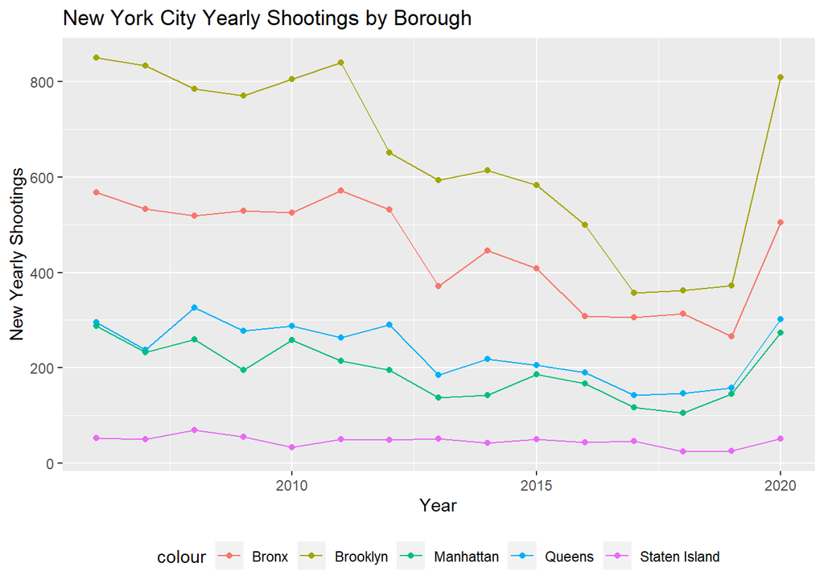

```r
queens_by_year %>% ggplot(aes(x = Occur_Year, y = New_Shootings_By_Year)) +
  geom_line(aes(color="Queens")) +
  geom_point(aes(color="Queens")) +

  geom_line(data=manhattan_by_year, aes(color="Manhattan")) +
  geom_point(data=manhattan_by_year, aes(color="Manhattan")) +

  geom_line(data=brooklyn_by_year, aes(color="Brooklyn")) +
  geom_point(data=brooklyn_by_year, aes(color="Brooklyn")) +

  geom_line(data=bronx_by_year, aes(color="Bronx")) +
  geom_point(data=bronx_by_year, aes(color="Bronx")) +

  geom_line(data=staten_island_by_year, aes(color="Staten Island")) +
  geom_point(data=staten_island_by_year, aes(color="Staten Island")) +

  theme(legend.position="bottom") +
  labs(title="New York City Yearly Shootings by Borough",
       y="New Yearly Shootings",
       x="Year")
```

The graphs here are easier on the eyes. We still see that Brooklyn leads the pack.

```r
# queens yearly model
mod_queens_yearly <- lm(New_Shootings_By_Year ~ Occur_Year, data=queens_by_year)
summary(mod_queens_yearly)
```

```
##
## Call:
## lm(formula = New_Shootings_By_Year ~ Occur_Year, data = queens_by_year)
##
## Residuals:
##     Min      1Q  Median      3Q     Max
## -58.376 -36.730  -8.693  19.775 125.917
##
## Coefficients:
##               Estimate Std. Error t value Pr(>|t|)
## (Intercept) 597.917476 130.364485   4.587  0.00051 ***
## Occur_Year   -0.023099   0.008259  -2.797  0.01512 *
## ---
## Signif. codes:  0 '***' 0.001 '**' 0.01 '*' 0.05 '.' 0.1 ' ' 1
##
## Residual standard error: 50.48 on 13 degrees of freedom
## Multiple R-squared:  0.3757, Adjusted R-squared:  0.3276
## F-statistic: 7.822 on 1 and 13 DF,  p-value: 0.01512
```

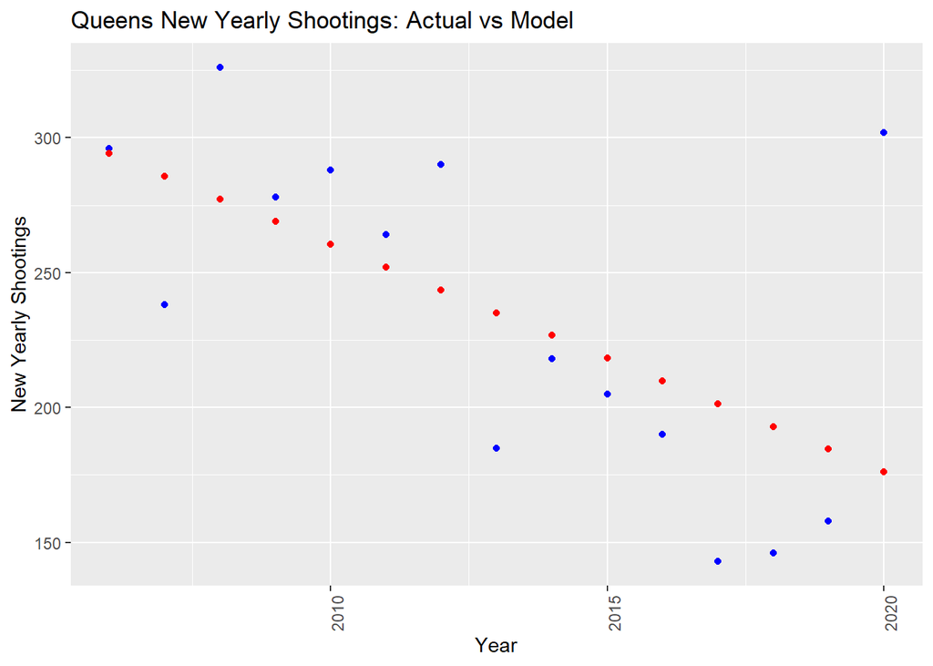

```r
queens_yearly_w_pred <- queens_by_year %>% mutate(pred = predict(mod_queens_yearly))

queens_yearly_w_pred %>% ggplot() +
  geom_point(aes(x = Occur_Year, y = New_Shootings_By_Year), color = "blue") +
  geom_point(aes(x = Occur_Year, y = pred), color = "red") +
  theme(legend.position="bottom",
       axis.text.x = element_text(angle=90)) +
  labs(title="Queens New Yearly Shootings: Actual vs Model",
       y="New Yearly Shootings",
       x="Year")
```

```r
# manhattan yearly model
mod_manhattan_yearly <- lm(New_Shootings_By_Year ~ Occur_Year, data=manhattan_by_year)
summary(mod_manhattan_yearly)
```

```
##
## Call:
## lm(formula = New_Shootings_By_Year ~ Occur_Year, data = manhattan_by_year)
##
## Residuals:
##     Min      1Q  Median      3Q     Max
## -56.725 -36.447  -5.301  17.042 131.618
##
## Coefficients:
##               Estimate Std. Error t value Pr(>|t|)
## (Intercept) 516.360127 129.374316   3.991  0.00154 **
## Occur_Year   -0.020478   0.008196  -2.499  0.02666 *
## ---
## Signif. codes:  0 '***' 0.001 '**' 0.01 '*' 0.05 '.' 0.1 ' ' 1
##
## Residual standard error: 50.09 on 13 degrees of freedom
## Multiple R-squared:  0.3244, Adjusted R-squared:  0.2725
## F-statistic: 6.243 on 1 and 13 DF,  p-value: 0.02666
```

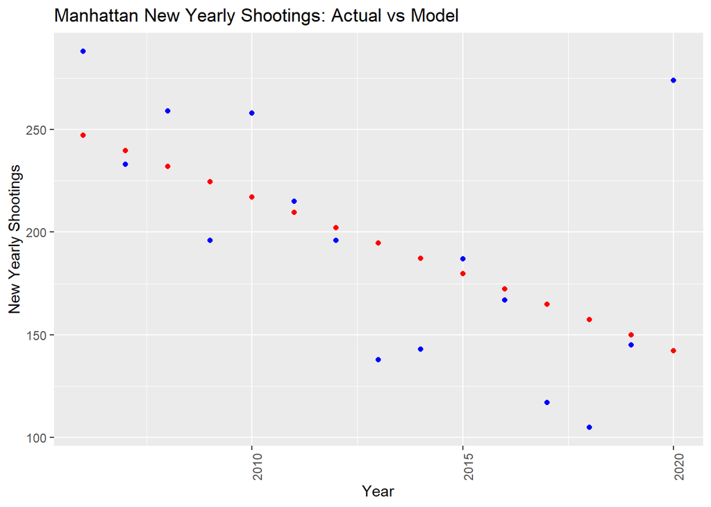

```r
manhattan_yearly_w_pred <- manhattan_by_year %>% mutate(pred = predict(mod_manhattan_yearly))

manhattan_yearly_w_pred %>% ggplot() +
  geom_point(aes(x = Occur_Year, y = New_Shootings_By_Year), color = "blue") +
  geom_point(aes(x = Occur_Year, y = pred), color = "red") +
  theme(legend.position="bottom",
       axis.text.x = element_text(angle=90)) +
  labs(title="Manhattan New Yearly Shootings: Actual vs Model",
       y="New Yearly Shootings",
       x="Year")
```

```r
# brooklyn yearly model
mod_brooklyn_yearly <- lm(New_Shootings_By_Year ~ Occur_Year, data=brooklyn_by_year)
summary(mod_brooklyn_yearly)
```

```
##
## Call:
## lm(formula = New_Shootings_By_Year ~ Occur_Year, data = brooklyn_by_year)
##
## Residuals:
##     Min      1Q  Median      3Q     Max
## -172.71  -57.73   -5.94    5.38  368.03
##
## Coefficients:
##               Estimate Std. Error t value Pr(>|t|)
## (Intercept) 1920.87640  338.79731   5.670 7.67e-05 ***
## Occur_Year    -0.08104    0.02146  -3.776  0.00231 **
## ---
## Signif. codes:  0 '***' 0.001 '**' 0.01 '*' 0.05 '.' 0.1 ' ' 1
##
## Residual standard error: 131.2 on 13 degrees of freedom
## Multiple R-squared:  0.523,  Adjusted R-squared:  0.4863
## F-statistic: 14.25 on 1 and 13 DF,  p-value: 0.002312
```

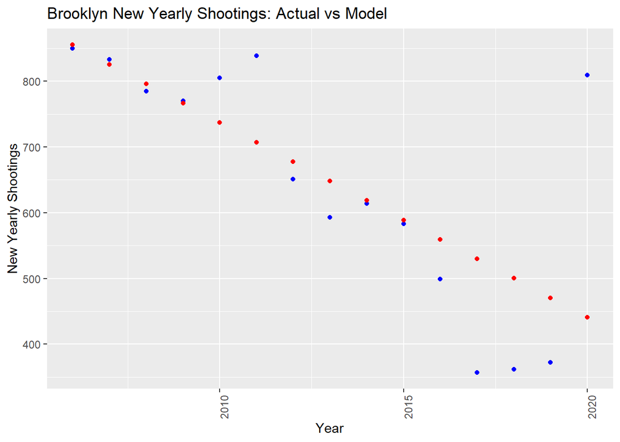

```r
brooklyn_yearly_w_pred <- brooklyn_by_year %>% mutate(pred = predict(mod_brooklyn_yearly))

brooklyn_yearly_w_pred %>% ggplot() +
  geom_point(aes(x = Occur_Year, y = New_Shootings_By_Year), color = "blue") +
  geom_point(aes(x = Occur_Year, y = pred), color = "red") +
  theme(legend.position="bottom",
       axis.text.x = element_text(angle=90)) +
  labs(title="Brooklyn New Yearly Shootings: Actual vs Model",
       y="New Yearly Shootings",
       x="Year")
```

```r
# bronx yearly model
mod_bronx_yearly <- lm(New_Shootings_By_Year ~ Occur_Year, data=bronx_by_year)
summary(mod_bronx_yearly)
```

```
##
## Call:
## lm(formula = New_Shootings_By_Year ~ Occur_Year, data = bronx_by_year)
##
## Residuals:
##     Min      1Q  Median      3Q     Max
## -84.840 -56.388  -4.294  20.893 183.951
##
## Coefficients:
##               Estimate Std. Error t value Pr(>|t|)
## (Intercept) 1218.41521  193.23504   6.305 2.72e-05 ***
## Occur_Year    -0.04914    0.01224  -4.014  0.00147 **
## ---
## Signif. codes:  0 '***' 0.001 '**' 0.01 '*' 0.05 '.' 0.1 ' ' 1
##
## Residual standard error: 74.82 on 13 degrees of freedom
## Multiple R-squared:  0.5534, Adjusted R-squared:  0.5191
## F-statistic: 16.11 on 1 and 13 DF,  p-value: 0.001473
```

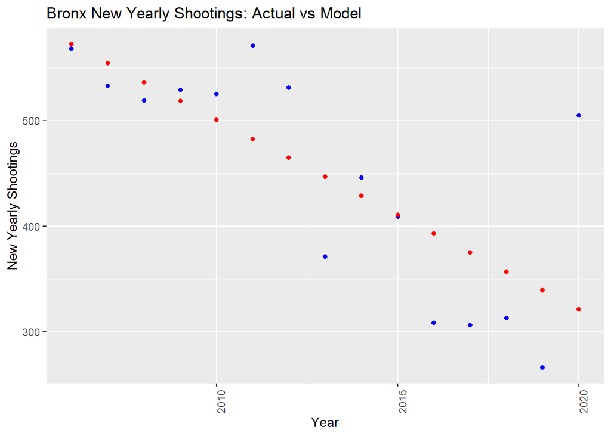

```r
bronx_yearly_w_pred <- bronx_by_year %>% mutate(pred = predict(mod_bronx_yearly))

bronx_yearly_w_pred %>% ggplot() +
  geom_point(aes(x = Occur_Year, y = New_Shootings_By_Year), color = "blue") +
  geom_point(aes(x = Occur_Year, y = pred), color = "red") +
  theme(legend.position="bottom",
       axis.text.x = element_text(angle=90)) +
  labs(title="Bronx New Yearly Shootings: Actual vs Model",
       y="New Yearly Shootings",
       x="Year")
```

```r
# staten_island yearly model
mod_staten_island_yearly <- lm(New_Shootings_By_Year ~ Occur_Year, data=staten_island_by_year)
summary(mod_staten_island_yearly)
```

```
##
## Call:
## lm(formula = New_Shootings_By_Year ~ Occur_Year, data = staten_island_by_year)
##
## Residuals:
##     Min      1Q  Median      3Q     Max
## -16.637  -3.925   1.097   5.204  15.625
##
## Coefficients:
##               Estimate Std. Error t value Pr(>|t|)
## (Intercept) 105.356312  25.404037   4.147  0.00115 **
## Occur_Year   -0.003745   0.001609  -2.327  0.03676 *
## ---
## Signif. codes:  0 '***' 0.001 '**' 0.01 '*' 0.05 '.' 0.1 ' ' 1
##
## Residual standard error: 9.836 on 13 degrees of freedom
## Multiple R-squared:  0.2941, Adjusted R-squared:  0.2398
## F-statistic: 5.416 on 1 and 13 DF,  p-value: 0.03676
```

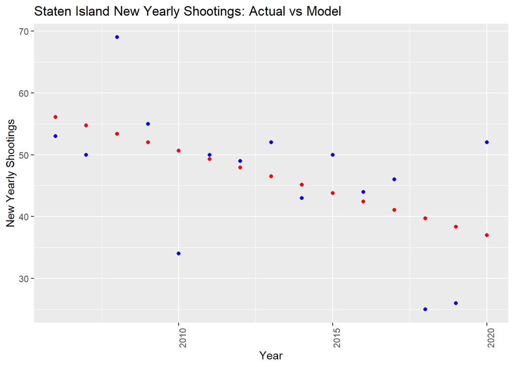

```r
staten_island_yearly_w_pred <- staten_island_by_year %>% mutate(pred = predict(mod_staten_island_yearly))

staten_island_yearly_w_pred %>% ggplot() +
  geom_point(aes(x = Occur_Year, y = New_Shootings_By_Year), color = "blue") +
  geom_point(aes(x = Occur_Year, y = pred), color = "red") +
  theme(legend.position="bottom",
       axis.text.x = element_text(angle=90)) +
  labs(title="Staten Island New Yearly Shootings: Actual vs Model",
       y="New Yearly Shootings",
       x="Year")
```

Linear models can now better fit the yearly data. This leads me to believe that there are some signals that vary by month rather than by year.

# Conclusion

It appears that there is a general downward trend in the number of shootings in New York City. However, there is a sudden increase in the number of shootings in 2020.

It appears that Brooklyn is the borough with the highest number of shootings. Bronx comes in second. Queens has come in third, but its record is much closer to that of Manhattan, which came in fourth. Staten Island has come in last for the number of shootings, which makes it sound like a good place to live in.

I have heard that New York City had a dark side through scandals from the news. I might have heard of some hearsay, like through rap songs, that Queens and Bronx might not be the safest places. I tried to give things a fair shake by trying to visualize how things truly were like, according to the data. I was surprised that Brooklyn took the top spot instead, although Bronx took second.

I have also heard that crime could be disproportionately distributed along racial lines. One way I thought about addressing this is to focus on the number of shooting incidents according to borough, ignoring the racial information about the perpetrators and victims alike.